# ORA with consensus cell types: SCPCP000009

Stephanie J. Spielman

2026-02-06

## Introduction

This notebook performs over-representation analysis (ORA) across gene sets comprised of cell-type–specific marker genes on the model residuals of `bulk ~ pseudobulk + (1+sample)` model for project SCPCP000009.

- We use permutation testing with 10^{4} replicates to assess significance, using an FDR correction for multiple testing.
- We take the median of residuals across samples to have one value per gene
- Test for both bulk and pseudobulk over-representation by testing if genes outlier status is associated with being a cell type marker gene.
  - Outliers in the bulk direction are identified as 2.5 standard deviations above the mean
  - Outliers in the pseudobulk are identified as -2.5 standard deviations below the mean

We use an odds ratio as our test statistic from this contingency table:

|  | Gene is outlier | Gene is not outlier |
| --- | --- | --- |
| Gene is cell type marker gene | A | B |
| Gene is not cell type marker gene | C | D |

(Here, “is cell type marker gene” is equivalent to “in the given gene set.”)

These are mathematically equivalent.

## Setup

```r
renv::load()

library(ggplot2)
theme_set(theme_bw())

set.seed(2025)
```

### Paths

```r
result_dir <- here::here("analysis", "pseudobulk-bulk-prediction", "results")
model_dir <- here::here(result_dir, "models")
ref_dir <- here::here("analysis", "pseudobulk-bulk-prediction", "data", "references")

panglao_file <- file.path(ref_dir, params$panglao_file)
stopifnot("Could not find panglao gene set file" = file.exists(panglao_file))


model_data_file <- file.path(
  model_dir,
  glue::glue("{params$project_id}_bulk-pseudobulk-data_threshold-0.tsv")
)


output_file <- file.path(
  result_dir,
  glue::glue("{params$project_id}_ORA-odds-ratios.tsv")
)
```

### Functions

```r
# This function establishes a contingency table of outlier/in geneset for a given data frame of residuals
#  and calculates odds ratios in both bulk and pseudobulk directions
analyze_outliers <- function(residual_df, geneset_ensembl_ids, outlier_threshold = params$sd_threshold) {

  ## Positive outliers: bulk direction
  or_bulk <- residual_df |>
    dplyr::mutate(
      outlier = scaled_summary_residual > outlier_threshold,
      in_geneset = ensembl_id %in% geneset_ensembl_ids
    ) |>
    dplyr::summarize(
      odds_num = sum(in_geneset & outlier) / sum(in_geneset & !outlier),
      odds_denom = sum(!in_geneset & outlier) / sum(!in_geneset & !outlier),
      odds_ratio = odds_num / odds_denom
    ) |>
    dplyr::pull(odds_ratio)



  ## Negative outliers: pseudobulk direction
  or_pseudobulk <- residual_df |>
    dplyr::mutate(
      outlier = scaled_summary_residual < (-1*outlier_threshold),
      in_geneset = ensembl_id %in% geneset_ensembl_ids
    ) |>
    dplyr::summarize(
      odds_num = sum(in_geneset & outlier) / sum(in_geneset & !outlier),
      odds_denom = sum(!in_geneset & outlier) / sum(!in_geneset & !outlier),
      odds_ratio = odds_num / odds_denom
    ) |>
    dplyr::pull(odds_ratio)

  data.frame(or_bulk = or_bulk, or_pseudobulk = or_pseudobulk)

}
```

## Read in data

```r
model_data <- readr::read_tsv(model_data_file)
geneset_df <- readr::read_tsv(panglao_file) |>
  dplyr::select(-other) |>
  tidyr::pivot_longer(
    -ensembl_id,
    names_to = "panglao_celltype",
    values_to = "gene_present"
  ) |>
  dplyr::filter(gene_present == 1) |>
  dplyr::select(-gene_present)
geneset_list <- split(geneset_df$ensembl_id, geneset_df$panglao_celltype)
```

## Calculate odds ratios

```r
# Summarize residuals to get one value per gene
summary_residual_df <- model_data |>
  dplyr::group_by(ensembl_id) |>
  # summarize based on parameter
  dplyr::summarize(
    summary_residual = do.call(params$summary_function, list(residual))
  ) |>
  # zscore for outlier detection
  dplyr::mutate(scaled_summary_residual = scale(summary_residual))

# Calculate ORs on real data
baseline_or_df <- geneset_list |>
  purrr::map(
    \(ensembl_ids) analyze_outliers(summary_residual_df, ensembl_ids)
  ) |>
  purrr::list_rbind(names_to = "geneset_cell_type")
```

Here are the odds ratios calculated directly from the data:

```r
baseline_or_df
```

| geneset_cell_type | or_bulk | or_pseudobulk |
| --- | --- | --- |
| Adrenergic neurons | 0.0000000 | 0.000000 |
| Anterior pituitary gland cells | 0.0000000 | 0.000000 |
| Astrocytes | 2.9384981 | 0.000000 |
| B cells | 0.0000000 | 0.000000 |
| B cells memory | 1.3765143 | 0.000000 |
| B cells naive | 1.3157147 | 0.000000 |
| Basophils | 1.2966230 | 1.172392 |
| Bergmann glia | 2.3557081 | 0.000000 |
| Cajal-Retzius cells | 1.1927644 | 0.000000 |
| Cholinergic neurons | 0.0000000 | 0.000000 |

[output cut: 58 more lines]

## Permutation test

To calculate P-values here, we shuffle the residual/gene_id relationship and perform a permutation test.

```r
shuffled_or_df <- 1:params$reps |>
  purrr::set_names(1:params$reps) |>
  purrr::map(\(i) {

    shuffled_df <- data.frame(
      ensembl_id = summary_residual_df$ensembl_id,
      scaled_summary_residual = sample(summary_residual_df$scaled_summary_residual, nrow(summary_residual_df))
    )

    geneset_list |>
      purrr::map(
        \(ensembl_ids) analyze_outliers(shuffled_df, ensembl_ids)
      ) |>
      purrr::list_rbind(names_to = "geneset_cell_type") |>
      # rename columns to with shuffled_ prefix for code clarity
      dplyr::rename(
        shuffled_or_bulk = or_bulk,
        shuffled_or_pseudobulk = or_pseudobulk
      )
  }) |> purrr::list_rbind(names_to = "replicate")
```

Below, we visualize the shuffled odds ratio distributions, with a red line representing the odds ratio calculated from the real data.

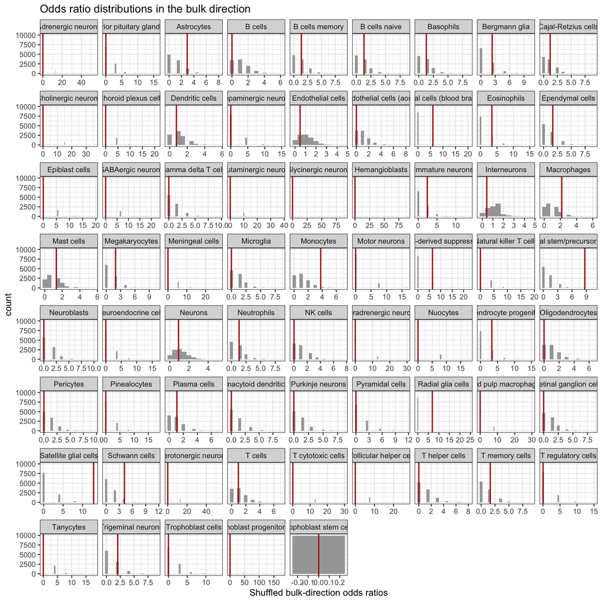

```r
ggplot(shuffled_or_df) +
  aes(x = shuffled_or_bulk) +
  geom_histogram(binwidth = 0.5, fill = "gray65") +
  facet_wrap(vars(geneset_cell_type), scales = "free_x") +
  geom_vline(
    data = baseline_or_df,
    aes(xintercept = or_bulk),
    color = "firebrick",
    linewidth = 0.75
  ) +
  labs(
    title = "Odds ratio distributions in the bulk direction",
    x = "Shuffled bulk-direction odds ratios"
  )
```

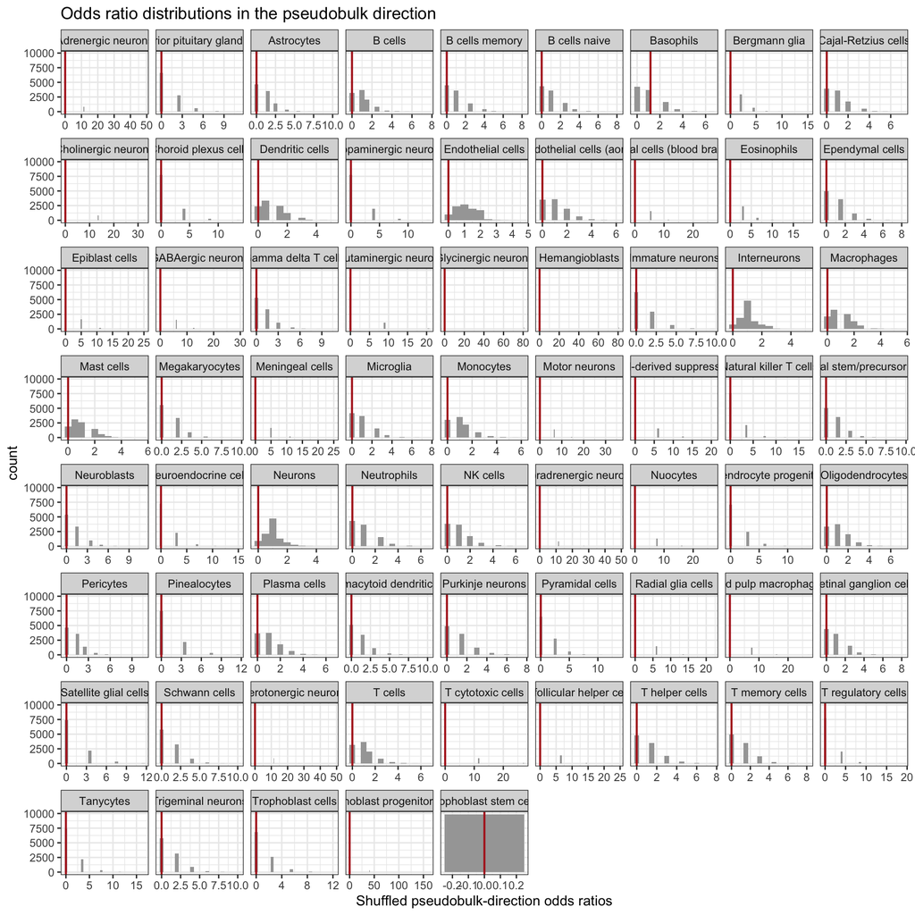

```r
ggplot(shuffled_or_df) +
  aes(x = shuffled_or_pseudobulk) +
  geom_histogram(binwidth = 0.5, fill = "gray65") +
  facet_wrap(vars(geneset_cell_type), scales = "free_x") +
  geom_vline(
    data = baseline_or_df,
    aes(xintercept = or_pseudobulk),
    color = "firebrick",
    linewidth = 0.75
  ) +
  labs(
    title = "Odds ratio distributions in the pseudobulk direction",
    x = "Shuffled pseudobulk-direction odds ratios"
  )
```

Next, we can calculate P-values for each gene set. We’ll also adjust P-values for multiple testing using FDR (Benjamini-Hochberg).

```r
permutation_pvalues <- names(geneset_list) |>
  purrr::set_names() |>
  purrr::map(
    \(geneset_name) {

    # This will have one row for the given geneset
    geneset_baseline_df <- baseline_or_df |>
      dplyr::filter(geneset_cell_type == geneset_name)

    # Define these variables for code clarity
    baseline_bulk_or <- geneset_baseline_df$or_bulk
    baseline_pseudobulk_or <- geneset_baseline_df$or_pseudobulk

    shuffled_or_df |>
      dplyr::filter(geneset_cell_type == geneset_name) |>
      # Calculate P-value as fraction of shuffled ORs >= baseline OR (with +1 correction on numerator & denominator to avoid p=0)
      dplyr::summarize(
        bulk = (sum(shuffled_or_bulk >= baseline_bulk_or) + 1) / (params$reps + 1),
        pseudobulk = (sum(shuffled_or_pseudobulk >= baseline_pseudobulk_or) + 1) / (params$reps + 1)
      ) |>
      # Correct for multiple testing with FDR
      tidyr::pivot_longer(
        everything(),
        names_to = "modality",
        values_to = "p_value"
      ) |>
      dplyr::mutate(p_adj_bh = p.adjust(p_value, method = "BH"))
  }) |>
  purrr::list_rbind(names_to = "geneset_cell_type")

# Join the odds ratios in with their pvalues, all in long format
permutation_results <- baseline_or_df |>
  tidyr::pivot_longer(
    starts_with("or_"),
    names_to = "modality",
    values_to = "odds_ratio"
  ) |>
  dplyr::mutate(modality = stringr::str_remove(modality, "^or_")) |>
  # and join in the pvalues
  dplyr::left_join(permutation_pvalues)
```

How many gene sets (cell types) are significant per modality, considering the BH-adjusted p-value?

```r
permutation_results |>
  dplyr::filter(p_adj_bh <= 0.05) |>
  dplyr::count(modality)
```

| modality | n |
| --- | --- |
| bulk | 3 |

What are those gene sets (cell types), if any?

```r
# wrangle a bit to make this easily human-readable
permutation_results |>
  dplyr::filter(p_adj_bh <= 0.05) |>
  dplyr::group_by(modality) |>
  dplyr::arrange(p_adj_bh, .by_group = TRUE)
```

| geneset_cell_type | modality | odds_ratio | p_value | p_adj_bh |
| --- | --- | --- | --- | --- |
| Neural stem/precursor cells | bulk | 8.661015 | 0.00069993 | 0.00139986 |
| Satellite glial cells | bulk | 12.833372 | 0.00179982 | 0.00359964 |
| Monocytes | bulk | 3.783546 | 0.02339766 | 0.04679532 |

## Export

We’ll export the odds ratios and p-values to a data frame.

```r
readr::write_tsv(permutation_results, output_file)
```